# Small Claims: Cleveland County 00-19

Leticia Calvillo, Fellow

Open Justice Oklahoma

2021-05-17

Background information: Why are we researching this topic? What is the expected product? A blog post? Analysis for an internal or external partner?

This project aims to shed light on the extent of medical debt in Oklahoma. The goal is to produce blog posts, fact sheets, and/or reports that emphasize the scale of the medicial debt problem in Oklahmoa and urge citizens to vote in favor of SQ 802.

# 1 Data sources

Where is the data from? The ojo database? OSCN? ODCR? Crime in Oklahoma reports?

The data is from the ojo database.

## 1.1 Timeframe

What years/months are you looking at? Year of case filing, first disposition, prison admission, etc.? Be as specific as possible.

The analysis aims to identify trends in medical debt cases over the past 20 years (2000-2019).

## 1.2 Geography

What courts/counties/states are you looking at?

This analysis focuses on small claims court cases in Cleveland County.

## 1.3 Variables

What variables did you use? What types of cases, crimes, etc.?

This project focuses on medical debt cases.

## 1.4 Query

If you’re using data from the OJO database, include the query you used to pull your data. This may be a function that starts `ojo_query_` or `dbGetQuery`.

```r
sc <- ojo_query_disps("CLEVELAND", "SC", 2000:2019)
```

This gives us over 137,239 rows of data. Each row in the table is a disposition; since there may be multiple dispositions per case, we should expect that the number of cases is somewhat lower.

# 2 Checking Data

## 2.1 Check for Completeness

If you’re using court data, you can use the `ojo_check_comp` to see how complete the data is.

```r
#ojo_check_comp(sc)

#completeness
```

## 2.2 Check for NAs

Detail the NAs and blank items in your data and, if necessary and possible, fill them in.

```r
nas <- sc %>%
  group_by(casenum) %>%
  filter(all(is.na(iss_plaint) | iss_plaint == ""))

nas
```

```
## # A tibble: 54,490 x 12
## # Groups:   casenum [43,286]
##    court   casenum   casetype file_year file_date  defname   iss_no iss_desc
##    <chr>   <chr>     <chr>        <int> <date>     <chr>     <chr>  <chr>
##  1 CLEVEL… SC-2000-… SC            2000 NA         SHEMPERT… 1      INDEBTEDNES…
##  2 CLEVEL… SC-2000-… SC            2000 NA         SHEMPERT… 1      INDEBTEDNES…
##  3 CLEVEL… SC-2000-… SC            2000 NA         COX, DAV… 1      INDEBTEDNES…
##  4 CLEVEL… SC-2000-… SC            2000 NA         HENSLEY,… 1      FORCIBLE EN…
##  5 CLEVEL… SC-2000-… SC            2000 NA         HOWARD, … 1      INDEBTEDNES…
##  6 CLEVEL… SC-2000-… SC            2000 NA         HOWARD, … 1      INDEBTEDNES…
##  7 CLEVEL… SC-2000-… SC            2000 NA         HARGRAVE… 1      INDEBTEDNES…
##  8 CLEVEL… SC-2000-… SC            2000 NA         CROWSON,… 1      INDEBTEDNES…
##  9 CLEVEL… SC-2000-… SC            2000 NA         BUTNER, … 1      INDEBTEDNES…
## 10 CLEVEL… SC-2000-… SC            2000 NA         CURRY, A… 1      INDEBTEDNESS
## # … with 54,480 more rows, and 4 more variables: iss_plaint <chr>,
## #   disp_date <date>, disp <chr>, disp_type <chr>
```

```r
nas_desc <- sc %>%
  group_by(casenum) %>%
  filter(all(is.na(iss_desc) | iss_desc == ""))

nas_desc
```

```
## # A tibble: 19 x 12
## # Groups:   casenum [14]
##    court   casenum    casetype file_year file_date  defname      iss_no iss_desc
##    <chr>   <chr>      <chr>        <int> <date>     <chr>        <chr>  <chr>
##  1 CLEVEL… SC-2000-0… SC            2000 NA         VANDERPOOL … 1      ""
##  2 CLEVEL… SC-2000-0… SC            2000 NA         CARTER JOSE… 1      ""
##  3 CLEVEL… SC-2000-0… SC            2000 NA         MURROW STEP… 1      ""
##  4 CLEVEL… SC-2000-0… SC            2000 NA         HERNANDEZ I… 1      ""
##  5 CLEVEL… SC-2000-0… SC            2000 NA         ABBOTT, KEV… 1      ""
##  6 CLEVEL… SC-2000-0… SC            2000 NA         LIMMERICK, … 1      ""
##  7 CLEVEL… SC-2000-0… SC            2000 NA         KOHLBACHER,… 1      ""
##  8 CLEVEL… SC-2000-0… SC            2000 NA         BURRIS, SHI… 1      ""
##  9 CLEVEL… SC-2000-0… SC            2000 NA         KIDS CONTEM… 1      ""
## 10 CLEVEL… SC-2000-0… SC            2000 NA         HEIMSOHEN, … 1      ""
## 11 CLEVEL… SC-2000-0… SC            2000 NA         LOUGHRIDGE,… 1      ""
## 12 CLEVEL… SC-2000-0… SC            2000 NA         GASCA, MARIA 1      ""
## 13 CLEVEL… SC-2000-0… SC            2000 NA         JALAPENO JO… 1      ""
## 14 CLEVEL… SC-2000-0… SC            2000 NA         GASCA, JOE   1      ""
## 15 CLEVEL… SC-2000-0… SC            2000 NA         SAILOR SUBS  1      ""
## 16 CLEVEL… SC-2000-0… SC            2000 NA         GARCIA, DIA… 1      ""
## 17 CLEVEL… SC-2001-0… SC            2001 NA         KARSTJENS, … 1      ""
## 18 CLEVEL… SC-2002-0… SC            2002 NA         RICHARDSON,… 1      ""
## 19 CLEVEL… SC-2008-0… SC            2008 NA         <NA>         1      ""
## # … with 4 more variables: iss_plaint <chr>, disp_date <date>, disp <chr>,
## #   disp_type <chr>
```

##Filling in missing plaintiff data

```r
connect_ojo()
```

Query oscn_party_names table for missing plaintiffs

```r
party_names <- dbGetQuery(ojo_db, glue_sql("SELECT * FROM oscn_party_names
                          WHERE court = 'CLEVELAND'
                          AND casenum IN ({nas$casenum*})",
                                           .con = ojo_db))
```

Filter for the first plaintiff name in each case

```r
plaint_names <- party_names %>%
  filter(party_type == "Plaintiff") %>%
  group_by(casenum) %>%
  slice(1) %>%
  select(casenum, iss_plaintiff = party)
```

Add new plaintiff names to nas_plaint dataframe

```r
nas_plaint <- nas%>%
  select(-iss_plaint) %>%
  left_join(plaint_names)
```

Remove rows with missing defendant names and add rows with newly queried defendant names

```r
sc2 <- sc%>%
  filter(!casenum %in% nas_plaint$casenum) %>%
  bind_rows(nas)
```

Check for missing defendant names in new dataframe

```r
nas <- sc2 %>%
  group_by(casenum) %>%
  filter(all(is.na(iss_plaint) | iss_plaint == ""))
```

```r
sc<- sc2
```

### 2.2.1 Extract debt amount from minutes

```r
mins <- ojo_query_mins("CLEVELAND", "SC", 2000:2019, min_code = "A/")
```

```
## [1] "SC 2000 minutes queried for OSCN courts: CLEVELAND"
## [1] "SC 2001 minutes queried for OSCN courts: CLEVELAND"
## [1] "SC 2002 minutes queried for OSCN courts: CLEVELAND"
## [1] "SC 2003 minutes queried for OSCN courts: CLEVELAND"
## [1] "SC 2004 minutes queried for OSCN courts: CLEVELAND"
## [1] "SC 2005 minutes queried for OSCN courts: CLEVELAND"
## [1] "SC 2006 minutes queried for OSCN courts: CLEVELAND"
## [1] "SC 2007 minutes queried for OSCN courts: CLEVELAND"
## [1] "SC 2008 minutes queried for OSCN courts: CLEVELAND"
## [1] "SC 2009 minutes queried for OSCN courts: CLEVELAND"
## [1] "SC 2010 minutes queried for OSCN courts: CLEVELAND"
## [1] "SC 2011 minutes queried for OSCN courts: CLEVELAND"
## [1] "SC 2012 minutes queried for OSCN courts: CLEVELAND"
## [1] "SC 2013 minutes queried for OSCN courts: CLEVELAND"
## [1] "SC 2014 minutes queried for OSCN courts: CLEVELAND"
## [1] "SC 2015 minutes queried for OSCN courts: CLEVELAND"
## [1] "SC 2016 minutes queried for OSCN courts: CLEVELAND"
## [1] "SC 2017 minutes queried for OSCN courts: CLEVELAND"
## [1] "SC 2018 minutes queried for OSCN courts: CLEVELAND"
## [1] "SC 2019 minutes queried for OSCN courts: CLEVELAND"
```

```r
mins <- mins %>%
  mutate(debt_amt = min_desc %>%
           str_remove_all("[:alpha:]|\\$|,") %>%
           str_squish %>%
           as.numeric)

debt_amts <- mins %>%
  select(casenum, debt_amt)
```

```r
new <- left_join(sc, debt_amts, by= "casenum")

sc <- new
```

```r
#sc <- sc %>%
  #group_by(casenum) %>%
  #slice(1)
```

There are 108,695 small claims cases. # Defining Measures

## 2.3 Debt Cases

Small claims cases generally involve an eviction (called “Forcible Entry and Detainer”) or a debt of less than $5,000. To narrow down our data set, we’ll limit to cases that involve debt.That information is found in the issue description (iss_desc) column.

```r
sc %>%
  count(iss_desc) %>%
  arrange(desc(n))
```

```
##                                                                    iss_desc
## 1                                                 FORCIBLE ENTRY & DETAINER
## 2                                                              INDEBTEDNESS
## 3                                                      INDEBTEDNESS >$1500.
## 4                                         FORCIBLE ENTRY & DETAINER >$1500.
## 5                                                   INDEBTEDNESS >$5000.00.
## 6                                      FORCIBLE ENTRY & DETAINER >$5000.00.
## 7                                            AFFIDAVIT FOR REPLEVIN >$1500.
## 8                                                    AFFIDAVIT FOR REPLEVIN
## 9                                                              INTERPLEADER
## 10
## 11                                                   INTERPLEADER >$1500.00
## 12                                        AFFIDAVIT FOR REPLEVIN >$5000.00.
## 13                                                        ASSAULT & BATTERY
## 14                                              REPLEVIN - CIVIL NO DAMAGES
```

[output cut: 73 more lines]

We use the str_detect() function to look for rows with the character string “FORC” in order to catch both “FORCIBLE ENTRY & DETAINER” and “FORCIBLE ENTRY & DETAINER >$1500”, plus any others that may be similar. Putting a ! before it means we want the rows where the string is not detected.

```r
debt <- sc %>%
  filter(!str_detect(iss_desc, "FORC|PROMISSORY|REPLEVIN|BREACH"))

debt %>%
  count(iss_desc) %>%
  arrange(desc(n))
```

```
##                                                                    iss_desc
## 1                                                              INDEBTEDNESS
## 2                                                      INDEBTEDNESS >$1500.
## 3                                                   INDEBTEDNESS >$5000.00.
## 4                                                              INTERPLEADER
## 5
## 6                                                    INTERPLEADER >$1500.00
## 7                                                         ASSAULT & BATTERY
## 8                                                           INDEBTNESS<1500
## 9  AGAINST GARNISHEE FILED BY PLAINTIFF MOTION  PHYSICIANS SURGICAL CENTERI
## 10                                              BAD FAITH INSURER LIABILITY
## 11                                                                  DAMAGES
## 12                            NOTICE OF TAKING ISSUE OF ANSWER OF GARNISHEE
## 13                                            AUTOMOBILE NEGLIGENCE >$1500.
## 14                                                            COUNTER CLAIM
```

[output cut: 51 more lines]

Medical debt cases will be filed with “Indebtedness” issues only. We discard all other cases.

```r
debt <- debt %>%
  filter(str_detect(iss_desc, "DEBT"))

debt %>%
  count(iss_desc) %>%
  arrange(desc(n))
```

```
##                  iss_desc     n
## 1            INDEBTEDNESS 44569
## 2    INDEBTEDNESS >$1500. 21430
## 3 INDEBTEDNESS >$5000.00.   823
## 4         INDEBTNESS<1500     4
## 5         INDEBTNESS>1500     2
## 6              INDEBTNESS     1
## 7       INDEBTNESS > 1500     1
```

## 2.4 Medical Providers

Next, we will use the mutate() function to classify the cases that have a medical provider plaintiff.

Let’s start by finding the most common plaintiffs:

```r
debt %>%
  count(iss_plaint) %>%
  arrange(desc(n))
```

```
##                                              iss_plaint     n
## 1                                                       25829
## 2                              OKLAHOMA STATE OF EX REL  4696
## 3                              NORMAN REGIONAL HOSPITAL  2476
## 4                    NORMAN REGIONAL HOSPITAL AUTHORITY  1683
## 5                         NORMAN REGIONAL HEALTH SYSTEM  1584
## 6                                           TOWER LOANS  1418
## 7                                         NOBLE FINANCE   900
## 8                                       TOWER LOANS INC   736
## 9                            CITIFINANCIAL SERVICES INC   564
## 10           INTEGRIS SOUTH OKLAHOMA CITY HOSPITAL CORP   560
## 11                INTEGRIS SOUTHWEST MEDICAL CENTER INC   536
## 12                  INTEGRIS BAPTIST MEDICAL CENTER INC   490
## 13                         WORLD ACCEPTANCE CORPORATION   428
## 14                                UNIVERSTY OF OKLAHOMA   410
```

[output cut: 5676 more lines]

Many of the most common plaintiffs are clearly medical providers or financial institutions. We use the case_when() function to classify all rows where one of the words is detected as being filed by a medical provider.

```r
debt <- debt %>%
  mutate(plaint_type = case_when(str_detect(iss_plaint, "HEALTH|CLINIC|MEDICAL") ~ "MEDICAL",
                                 str_detect(iss_plaint, "BANK|FCU") ~ "OTHER",
                                 TRUE ~ "UNKNOWN"))
```

To check how many we were able to classify, we’ll look at the count in the plaint_type column.

```r
debt %>%
  count(plaint_type) %>%
  arrange(desc(n))
```

```
##   plaint_type     n
## 1     UNKNOWN 61742
## 2     MEDICAL  4015
## 3       OTHER  1073
```

To get the most common plaintiffs that are not classified yet:

```r
debt %>%
  filter(plaint_type == "UNKNOWN") %>%
  count(iss_plaint) %>%
  arrange(desc(n))
```

```
##                                              iss_plaint     n
## 1                                                       25829
## 2                              OKLAHOMA STATE OF EX REL  4696
## 3                              NORMAN REGIONAL HOSPITAL  2476
## 4                    NORMAN REGIONAL HOSPITAL AUTHORITY  1683
## 5                                           TOWER LOANS  1418
## 6                                         NOBLE FINANCE   900
## 7                                       TOWER LOANS INC   736
## 8                            CITIFINANCIAL SERVICES INC   564
## 9            INTEGRIS SOUTH OKLAHOMA CITY HOSPITAL CORP   560
## 10                         WORLD ACCEPTANCE CORPORATION   428
## 11                                UNIVERSTY OF OKLAHOMA   410
## 12                                            CHECKMATE   333
## 13                                   COASTAL CREDIT LLC   309
## 14                         FRIENDS FEDERAL CREDIT UNION   293
```

[output cut: 5553 more lines]

I came up with the following classification:

```r
debt <- debt %>%
  mutate(plaint_type = case_when(str_detect(iss_plaint,
"HEALTH|CLINIC|MEDICAL|HOSPITAL| MD|ANESTHESIA| CRNA|ENDOSCOPY| DDS| DO|MRI|NORMAN\\sREGIONAL\\sHOPITAL\\sAUTHORITY|PEDIATRICS|AMBULATORY|RADIOLOGY|SMILE\\sSOLUTIONS|SURGICAL|INTEGRIS|NEUROSURGICAL|ORTHOPAEDIC|GI\\sOF\\sNORMAN|ORTHOPEDIC|NEUROSURGERY|PAIN\\sASSOCIATES|UROLOGY|ORTHOPEADIC|ANKLE\\sSPECIALIST|FOOT\\s&\\sANKLE|CRANIOFACIAL|OU\\sPHYSICIANS") ~ "MEDICAL",
                                 str_detect(iss_plaint, "BANK|FCU|CREDIT|LOAN|FINANCIAL|LOANS|CITIFINANCIAL|FINAN|ELECTRIC|CASH|CHECKMATE|SYSCO|REALTY|SAND|BONDS|PROPERTIES|WORLD\\sACCEPTANCE\\sCORP|CROSSROADS\\sKIDZ\\sCLUB|INVESTMENT|PROPERTY|UNIVERSTY\\sOF\\sOKLAHOMA|AUTO|GREENBRIAR\\sKINGSPARK\\sHOA|BRSI|JEEP|MOTOR|OKLAHOMA\\sSTATE\\sOF\\sEX|HOMEOWNERS") ~ "OTHER",
                                 TRUE ~ "UNKNOWN"))
```

This gives us a count of:

```r
debt %>%
  count(plaint_type) %>%
  arrange(desc(n))
```

```
##   plaint_type     n
## 1     UNKNOWN 36285
## 2       OTHER 17860
## 3     MEDICAL 12685
```

```r
debt %>%
  filter(plaint_type == "UNKNOWN") %>%
  count(iss_plaint) %>%
  arrange(desc(n))
```

```
##                                              iss_plaint     n
## 1                                                       25829
## 2                                UNIVERSITY OF OKLAHOMA   143
## 3                               CHRISTIANSON, BRADLEY G    84
## 4                                     HILL, JOHN B BUCK    51
## 5                                               ACG INC    48
## 6                                    RIDGEWAY, JUDITH A    48
## 7                                         RENT A CENTER    40
## 8                                           ASKINS, J B    38
## 9                                            J B ASKINS    37
## 10                                           RTO OK INC    34
## 11                             SLEEP CENTERS OF AMERICA    34
## 12                                     BITS OF STARDUST    33
## 13                               CARDINAL CREEK HOA INC    33
## 14                                 HALLMAN & ASSOCIATES    33
```

[output cut: 4724 more lines]

This gives us the most common medical plaintiffs:

```r
debt %>%
  filter(plaint_type == "MEDICAL") %>%
  count(iss_plaint) %>%
  arrange(desc(n))
```

```
##                                             iss_plaint    n
## 1                             NORMAN REGIONAL HOSPITAL 2476
## 2                   NORMAN REGIONAL HOSPITAL AUTHORITY 1683
## 3                        NORMAN REGIONAL HEALTH SYSTEM 1584
## 4           INTEGRIS SOUTH OKLAHOMA CITY HOSPITAL CORP  560
## 5                INTEGRIS SOUTHWEST MEDICAL CENTER INC  536
## 6                  INTEGRIS BAPTIST MEDICAL CENTER INC  490
## 7                      NORMAN ANESTHESIA PROVIDERS, PC  260
## 8                    INTEGRIS SOUTHWEST MEDICAL CENTER  227
## 9                           PURCELL MUNICIPAL HOSPITAL  211
## 10                              LEONARD, JASON E MD PC  185
## 11                             NORMAN NEUROSURGICAL PC  181
## 12                          EMERGENCY MEDICAL SERVICES  173
## 13                EMERGENCY MEDICAL SERVICES AUTHORITY  159
## 14                                       NORMAN CLINIC  128
```

[output cut: 407 more lines]

To get a data frame with only the medical debt cases, filter on the plaint_type variable we created.

```r
debt <- debt %>%
  filter(plaint_type == "MEDICAL")
```

# 3 Summarizing and Visualizing Data

## 3.1 Summarizing to the case level

.

```r
debt <- debt %>%
  group_by(casenum) %>%
  slice(1)
```

## 3.2 Summarizing by year

```r
year_sum <- debt %>%
  ungroup %>%
  count(file_year)
```

Now we have a data frame with the number of cases filed in each year. To create a simple line plot with this data:

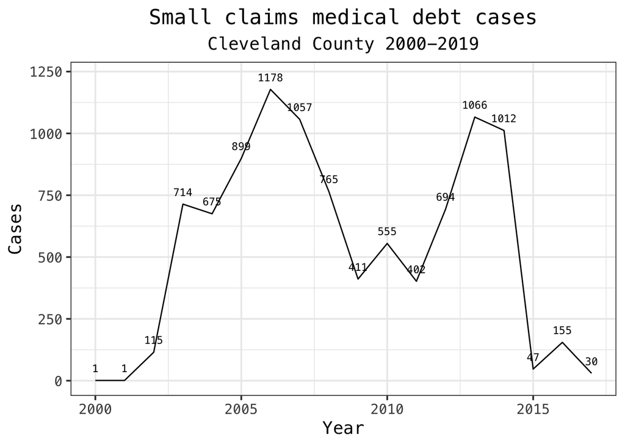

```r
ggplot(year_sum, aes(file_year, n)) +
  geom_line() +
  geom_text(aes(y = n + 50, label = n), family = "Menlo", size = 3) +
  xlab("Year") + ylab("Cases") +
  ylim(0, NA) +
  theme_ojo() +
  theme(plot.title = element_text(hjust = 0.5)) +
  theme(plot.subtitle = element_text(hjust = 0.5)) +
  labs(title = "Small claims medical debt cases",
       subtitle = "Cleveland County 2000-2019")
```

##summarizing by provider The most common plaintiffs seem to be NORMAN REGIONAL, INTEGRIS, NORMAN ANESTHESIA PROVIDERS. Again, we’ll use the str_detect() function to classify the cases.

```r
debt <- debt %>%
  mutate(plaint_cat = case_when(str_detect(iss_plaint, "NORMAN REGIONAL") ~ "NORMAN REGIONAL HEALTH",
                                str_detect(iss_plaint, "INTEGRIS") ~ "INTEGRIS",
                                str_detect(iss_plaint, "NORMAN ANESTHESIA PROVIDERS") ~ "NORMAN ANESTHESIA PROVIDERS",
                                TRUE ~ "OTHER"))
```

Now we can see how many cases each group filed each year:

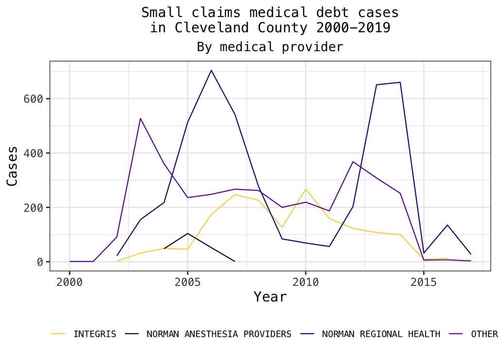

```r
plaint_sum <- debt %>%
  ungroup %>% # Our data frame is still grouped by casenum from the code above; ungroup to summarize using broader groups
  count(file_year, plaint_cat)

ggplot(plaint_sum, aes(file_year, n, group = plaint_cat, color = plaint_cat)) +
  geom_line() +
  xlab("Year") + ylab("Cases")+
  ylim(0, NA) + # Extends y-axis down to zero
  theme_ojo() + # Adds ojo styling to the plot
  theme(legend.title=element_blank())+
  theme(plot.title = element_text(hjust = 0.5, size = 14)) +
  theme(plot.subtitle = element_text(hjust = 0.5, size = 13)) +
  theme(legend.text=element_text(size = 9))+
  theme(legend.position="bottom")+
  labs(title = "Small claims medical debt cases\nin Cleveland County 2000-2019",
       subtitle = "By medical provider") +
  scale_color_manual(values = ojo_pal) # Gives lines colors from ojo's palette
```

### 3.2.1 Find median debt amount

Created a new dataframe with the median medical debt amount by file_year.

```r
debt_new <-debt %>%
  group_by(file_year) %>%
  summarise(n_cases = n(),
            n_cases_with_debt = sum(!is.na(debt_amt)),
            avg = median(debt_amt, na.rm = TRUE)) %>%
  mutate(pct_with_debt = n_cases_with_debt/n_cases)

debt_new
```

```
## # A tibble: 18 x 5
##    file_year n_cases n_cases_with_debt   avg pct_with_debt
##        <int>   <int>             <int> <dbl>         <dbl>
##  1      2000       1                 0    NA             0
##  2      2001       1                 0    NA             0
##  3      2002     115                 0    NA             0
##  4      2003     714                 0    NA             0
##  5      2004     675                 0    NA             0
##  6      2005     899                 0    NA             0
##  7      2006    1178                 0    NA             0
##  8      2007    1057                 0    NA             0
##  9      2008     765                 0    NA             0
## 10      2009     411                 0    NA             0
## 11      2010     555                 0    NA             0
## 12      2011     402                 0    NA             0
## 13      2012     694                 0    NA             0
## 14      2013    1066                 0    NA             0
## 15      2014    1012                 0    NA             0
## 16      2015      47                 0    NA             0
## 17      2016     155                 0    NA             0
## 18      2017      30                 0    NA             0
```

### 3.2.2 Graph median medical debt by year

[figure not shown]

```r
ggplot(debt_new, aes(x= file_year, y= avg)) +
  geom_line() +
  #geom_text(aes(y = avg + 50, label = avg), family = "Menlo", size = 3) +
  xlab("Year") + ylab("Amount") +
  ylim(0, NA) + # Extends y-axis down to zero
  theme_ojo() +
  theme(plot.title = element_text(hjust = 0.5)) +
  theme(plot.subtitle = element_text(hjust = 0.5)) +
  labs(title = "Median medical debt amount",
       subtitle = "Cleveland County 2000-2019")
```

## 3.3 Summary 1

- How you summarized and why To answer the original question, I summarized by year. To take a deeper look into what is behind the general trends, I also summarized by medical provider.
- How you visualized the data I used a line graph to visualize the data.
- Potential leads and trends